# surface-pfp

```r
library(rtorf)
library(data.table)
```

```r
cate = c("aircraft-pfp",
         "aircraft-insitu",
         "aircraft-flask",
         "surface-insitu",
         "surface-flask",
         "surface-pfp",
         "tower-insitu",
         "aircore",
         "shipboard-insitu",
         "shipboard-flask")

obs <- "Z:/torf/obspack_ch4_1_GLOBALVIEWplus_v5.1_2023-03-08/data/nc/"
index <- obs_summary(obs = obs,
                     categories = cate)
```

```
#> Number of files of index: 429
#>               sector     N
#>               <char> <int>
#>  1:     aircraft-pfp    40
#>  2:  aircraft-insitu    15
#>  3:    surface-flask   106
#>  4:   surface-insitu   174
#>  5:   aircraft-flask     4
#>  6:          aircore     1
#>  7:      surface-pfp    33
#>  8:     tower-insitu    51
#>  9:  shipboard-flask     4
#> 10: shipboard-insitu     1
#> 11:    Total sectors   429
#> Detected 190 files with agl
#> Detected 239 files without agl
```

Now we read the `surface-pfp` using the function `obs_read_nc`. `solar_time` is included for surface, so we `TRUE` that argument.

```r
datasetid <- "surface-pfp"
df <- obs_read_nc(index = index,
                  categories = datasetid,
                  solar_time = TRUE,
                  verbose = TRUE)
```

```
#> Searching surface-pfp...
#> 1: ch4_amt_surface-pfp_1_allvalid-107magl.nc
#> 2: ch4_bao_surface-pfp_1_allvalid-300magl.nc
#> 3: ch4_crv_surface-pfp_1_allvalid-32magl.nc
#> 4: ch4_inx_surface-pfp_1_allvalid-121magl.nc
#> 5: ch4_inx_surface-pfp_1_allvalid-125magl.nc
#> 6: ch4_inx_surface-pfp_1_allvalid-129magl.nc
#> 7: ch4_inx_surface-pfp_1_allvalid-130magl.nc
#> 8: ch4_inx_surface-pfp_1_allvalid-137magl.nc
#> 9: ch4_inx_surface-pfp_1_allvalid-39magl.nc
#> 10: ch4_inx_surface-pfp_1_allvalid-40magl.nc
#> 11: ch4_inx_surface-pfp_1_allvalid-54magl.nc
#> 12: ch4_klm_surface-pfp_1_allvalid-4magl.nc
#> 13: ch4_lef_surface-pfp_1_allvalid-244magl.nc
#> 14: ch4_lef_surface-pfp_1_allvalid-396magl.nc
```

[output cut: 19 more lines]

Now we check the data

```r
df
```

```
#>         year month   day  hour minute second       time start_time
#>        <int> <int> <int> <int>  <int>  <int>      <int>      <int>
#>     1:  2008    11    23    16     22     49 1227457369 1227457369
#>     2:  2008    11    23    16     29     19 1227457759 1227457759
#>     3:  2008    11    23    16     35     54 1227458154 1227458154
#>     4:  2008    11    23    16     40     21 1227458421 1227458421
#>     5:  2008    11    23    16     44     47 1227458687 1227458687
#>    ---
#> 43159:  2021    12    23    20     45      5 1640292305 1640292305
#> 43160:  2021    12    25    20     45      8 1640465108 1640465108
#> 43161:  2021    12    27    20     45      6 1640637906 1640637906
#> 43162:  2021    12    29    20     45     13 1640810713 1640810713
#> 43163:  2021    12    31    20     45     10 1640983510 1640983510
#>        midpoint_time             datetime time_decimal time_interval
#>                <int>               <char>        <num>         <int>
```

[output cut: 141 more lines]

Now we can process the data. We first filter for observations within our spatial domain:

## Checks and definitions

```r
north <- 80
south <- 10
west <- -170
east <- -50
max_altitude <- 8000
yy <- 2020
evening <- 14
```

We check altitude, intake_height, altitude_final and elevation. altitude_final is a column from intake_height, added to match column from obs_read text files.

```r
df[, c("altitude", "altitude_final", "intake_height", "elevation",
       "dataset_selection_tag",
              "site_name")]
```

```
#>        altitude altitude_final intake_height elevation dataset_selection_tag
#>           <num>          <num>         <num>     <num>                <char>
#>     1:    160.4            108           108      52.4      allvalid-107magl
#>     2:    160.4            108           108      52.4      allvalid-107magl
#>     3:    160.4            108           108      52.4      allvalid-107magl
#>     4:    160.4            108           108      52.4      allvalid-107magl
#>     5:    160.4            108           108      52.4      allvalid-107magl
#>    ---
#> 43159:    708.0            457           457     251.0      allvalid-457magl
#> 43160:    708.0            457           457     251.0      allvalid-457magl
#> 43161:    708.0            457           457     251.0      allvalid-457magl
#> 43162:    708.0            457           457     251.0      allvalid-457magl
#> 43163:    708.0            457           457     251.0      allvalid-457magl
#>            site_name
#>               <char>
#>     1: Argyle, Maine
#>     2: Argyle, Maine
#>     3: Argyle, Maine
#>     4: Argyle, Maine
#>     5: Argyle, Maine
#>    ---
#> 43159:  Moody, Texas
#> 43160:  Moody, Texas
#> 43161:  Moody, Texas
#> 43162:  Moody, Texas
#> 43163:  Moody, Texas
```

The temporal range of data is

```r
range(df$year)
```

```
#> [1] 2005 2021
```

We also check for dimensions of data

```r
dim(df)
```

```
#> [1] 43163    53
```

## Filters

```r
df <- df[year == yy]

df <- df[altitude_final < max_altitude &
           latitude < north &
           latitude > south &
           longitude < east &
           longitude > west]
dim(df)
```

```
#> [1] 2205   53
```

```r
dfa <- df[,
          max(altitude_final),
          by = site_code] |> unique()

names(dfa)[2] <- "max_altitude"
dfa
```

```
#>     site_code max_altitude
#>        <char>        <num>
#>  1:       AMT       108.00
#>  2:       CRV        31.70
#>  3:       LEF       396.00
#>  4:       LEW        95.00
#>  5:       MBO        11.30
#>  6:       MRC        60.97
#>  7:       MSH        46.30
#>  8:       MWO        45.90
#>  9:       NWR         3.20
#> 10:       SCT       304.80
#> 11:       SGP        60.00
#> 12:       WBI       378.90
#> 13:       WGC        89.10
#> 14:       WKT       122.00
```

### Key Time

Here we need to start time columns. The function `obs_addtime` adds time columns `timeUTC`, `timeUTC_start` which shows the start time of each observation and `timeUTC_end` which shows the end time for each observation.

```r
df2 <- obs_addtime(df)
```

```
#> Adding timeUTC
#> Adding timeUTC_start
#> Adding timeUTC_end
#> Found time_interval
```

Then we need a *key_time* to aggregate data. This can be done using UTC, solar, or local time. The normal approach is using afternoon solar or local time.

#### Hierarchy of solar or local time

1. Solar time
2. Local time with columns `site_utc2lst`
3. Local time longitude

> solar time (default)

Here we select the hours of interest and then aggregate data by year, month and day of solar time. In this way, we will have one information per day. however this approach is not appropriate for aircraft which are aggregated every 10 or 20 seconds. Hence we need to aggregate data by one time column. Also, this helps to generate the receptor info files including hour, minute and second. Hence, *we need to add solar or local time column*.

```r
df2$solar_time <- obs_addstime(df2)
```

> local time with column `site_utc2lst`

> local time longitude

#### Cut time

Now we have they key column time, we can cut it accordingly.

```r
df2$solar_time_cut <- cut(x = df2$solar_time,
                          breaks = "1 hour") |>
  as.character()
```

How we can check the solar time and the cut solar time. Please note that solar_time_cut, the column that it will be used to aggregate data

How we filter for the required solar time, in this case 14.

```r
df3 <- df2[hour_st %in% evening]
df3[, c("solar_time", "solar_time_cut")]
```

```
#>                solar_time      solar_time_cut
#>                    <POSc>              <char>
#>    1: 2020-01-09 14:43:43 2020-01-09 14:00:00
#>    2: 2020-01-10 14:43:23 2020-01-10 14:00:00
#>    3: 2020-03-13 14:46:01 2020-03-13 14:00:00
#>    4: 2020-03-15 14:46:20 2020-03-15 14:00:00
#>    5: 2020-03-17 14:47:01 2020-03-17 14:00:00
#>   ---
#> 1047: 2020-12-22 14:14:08 2020-12-22 14:00:00
#> 1048: 2020-12-24 14:13:21 2020-12-24 14:00:00
#> 1049: 2020-12-26 14:12:29 2020-12-26 14:00:00
#> 1050: 2020-12-28 14:11:32 2020-12-28 14:00:00
#> 1051: 2020-12-30 14:10:46 2020-12-30 14:00:00
```

Now there are 1051 observations and before filtering 2205. At this point we can calculate the averages of several columns by the cut time. The function `obs_agg` does this aggregation as shown in the following lines of code. The argument `gby` establish the function used to aggregate `cols`. I need to aggregate the data by date (year, month, date), because it is already filtered by the hours of interest. Then, I would have 1 observation per day.

As standard, let us define `key_time` as `solar_time`. The `obs_agg` function will aggregate the desired data by that column.

```r
df3$key_time <- df3$solar_time_cut
```

```r
df4 <- obs_agg(dt = df3,
               cols = c("value",
                        "latitude",
                        "longitude",
                        "site_utc2lst"),
               verbose = T,
               byalt = TRUE)
```

```
#> Adding time
```

Now there are 1050 observations, 1155 less observations. Here we add the column `max_altitude` to identify the max altitude by site.

```r
df4[,
    max_altitude := max(altitude_final),
    by = site_code]
df4[,
    c("site_code",
      "altitude_final",
      "max_altitude")] |> unique()
```

```
#>     site_code altitude_final max_altitude
#>        <char>          <num>        <num>
#>  1:       AMT         108.00       108.00
#>  2:       LEF         396.00       396.00
#>  3:       LEW          95.00        95.00
#>  4:       MRC          60.97        60.97
#>  5:       MSH          46.30        46.30
#>  6:       NWR           3.20         3.20
#>  7:       SCT         304.80       304.80
#>  8:       SGP          60.00        60.00
#>  9:       WBI         378.90       378.90
#> 10:       WGC          89.10        89.10
#> 11:       WKT         122.00       122.00
```

## Master

Before generating the receptors list, we have the database with all the required information

```r
master <- df4
```

We may replace missing values with a nine nines. Here is commented

#master[is.na(master)] <- 999999999

We transform the time variables to character and round coordinates with 4 digits

```r
master$timeUTC <- as.character(master$timeUTC)
master$local_time <- as.character(master$local_time)
master$latitude <- round(master$latitude, 4)
master$longitude <- round(master$longitude, 4)
```

## Save master

Finally we save the master file

```r
out <- tempfile()
```

### txt

```r
message(paste0(out,"_", datasetid, ".txt\n"))
```

```
#> C:\Users\sibarrae\AppData\Local\Temp\Rtmpe0zNW8\filea908367c656d_surface-pfp.txt
```

```r
fwrite(master,
       paste0(out,"_", datasetid, ".txt"),
       sep = " ")
```

### csv

```r
message(paste0(out,"_", datasetid, ".csv\n"))
```

```
#> C:\Users\sibarrae\AppData\Local\Temp\Rtmpe0zNW8\filea908367c656d_surface-pfp.csv
```

```r
fwrite(master,
       paste0(out,"_", datasetid, ".csv"),
       sep = ",")
```

### csvy

CSVY are csv files with a YAML header to include metadata in tabulated text files

```r
cat("\nAdding notes in csvy:\n")
```

```
#>
#> Adding notes in csvy:
```

```r
notes <- c(paste0("sector: ", datasetid),
           paste0("timespan: ", yy),
           paste0("spatial_limits: north = ", north, ", south = ", south, ", east = ", east, ", west = ", west),
           paste0("altitude: < ", max_altitude),
           paste0("hours: ", evening),
           "local_time: used solar_time")

cat(notes, sep = "\n")
```

```
#> sector: surface-pfp
#> timespan: 2020
#> spatial_limits: north = 80, south = 10, east = -50, west = -170
#> altitude: < 8000
#> hours: 14
#> local_time: used solar_time
```

```r
message(paste0(out,"_", datasetid, ".csvy\n"))
```

```
#> C:\Users\sibarrae\AppData\Local\Temp\Rtmpe0zNW8\filea908367c656d_surface-pfp.csvy
```

```r
obs_write_csvy(dt = master,
               notes = notes,
               out = paste0(out,"_", datasetid, ".csvy"))
```

```r
obs_read_csvy(paste0(out,"_", datasetid, ".csvy"))
```

```
#>  [1] "---"
#>  [2] "name: Metadata "
#>  [3] "sector: surface-pfp"
#>  [4] "timespan: 2020"
#>  [5] "spatial_limits: north = 80, south = 10, east = -50, west = -170"
#>  [6] "altitude: < 8000"
#>  [7] "hours: 14"
#>  [8] "local_time: used solar_time"
#>  [9] "structure: "
#> [10] "Classes 'data.table' and 'data.frame':\t1050 obs. of  20 variables:"
#> [11] " $ timeUTC                  : chr  \"2020-01-09 14:00:00\" \".."
#> [12] " $ site_code                : chr  \"AMT\" \"AMT\" ..."
#> [13] " $ altitude_final           : num  108 108 108 108 108 ..."
#> [14] " $ type_altitude            : num  NA NA NA NA NA ..."
#> [15] " $ lab_1_abbr               : chr  \"NOAA\" \"NOAA\" ..."
```

[output cut: 70 more lines]

## Receptors

Now we can do the last step which is generating the receptor list files. Now we filter selected columns

```r
receptor <- master[, c("site_code",
                     "year",
                     "month",
                     "day",
                     "hour",
                     "minute",
                     "second",
                     "latitude",
                     "longitude",
                     "altitude_final",
                     "type_altitude",
                     "time_decimal")]
```

We can round altitude also

```r
receptor$altitude_final <- round(receptor$altitude_final)
```

Now we can format time variables with two digits

```r
receptor <- obs_format(receptor,
                        spf =  c("month", "day",
                                 "hour", "minute", "second"))
```

We have a column that indicate AGL or ASL

```r
receptor_agl <- receptor[type_altitude == 0]
receptor_asl <- receptor[type_altitude == 1]
```

Finally, we save the receptors

```r
if(nrow(receptor_agl) > 0) {
  message(paste0(out, "_", datasetid, "_receptor_AGL.txt"), "\n")

  fwrite(x = receptor_agl,
         file = paste0(out, "_", datasetid, "_receptor_AGL.txt"),
         sep = " ")
}
```

```
#> C:\Users\sibarrae\AppData\Local\Temp\Rtmpe0zNW8\filea908367c656d_surface-pfp_receptor_AGL.txt
```

```r
if(nrow(receptor_asl) > 0) {
  message(paste0(out, "_", datasetid, "_receptor_ASL.txt"), "\n")

  fwrite(x = receptor_asl,
         file = paste0(out, "_", datasetid, "receptor_ASL.txt"),
         sep = " ")

}
```

## Plot

Finally, we just plot some data, run it locally

```
#> Found the following sites:
#>  [1] AMT LEF LEW MRC MSH NWR SCT SGP WBI WGC WKT
#> Plotting the following sites:
#> [1] AMT LEF
#> png
#>   2
```

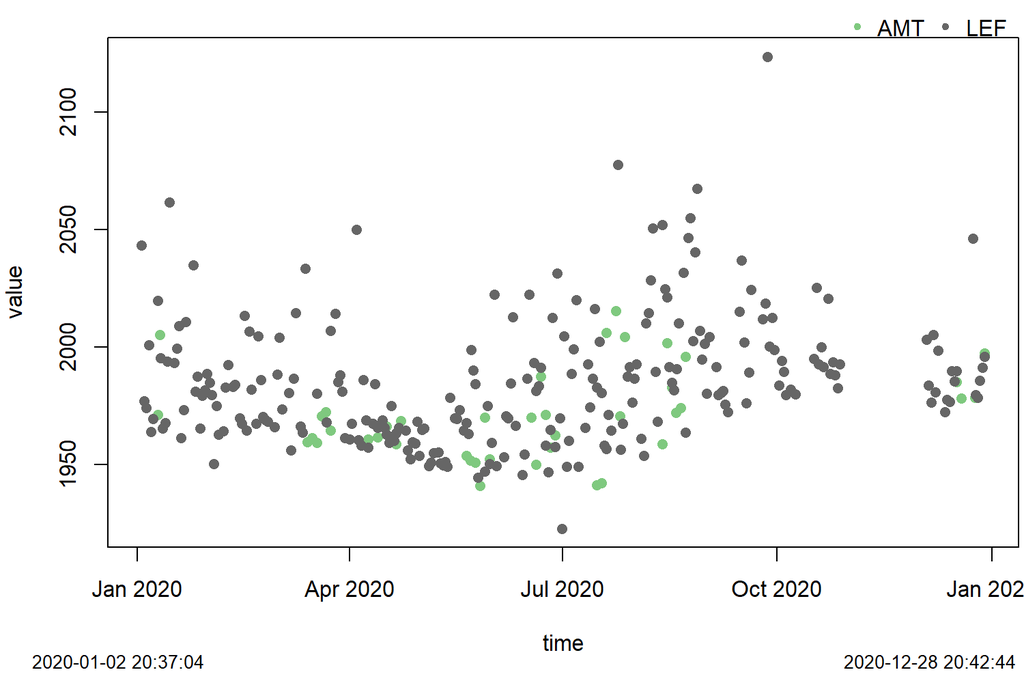

```r
obs_plot(df4, time = "timeUTC", yfactor = 1e9)
```

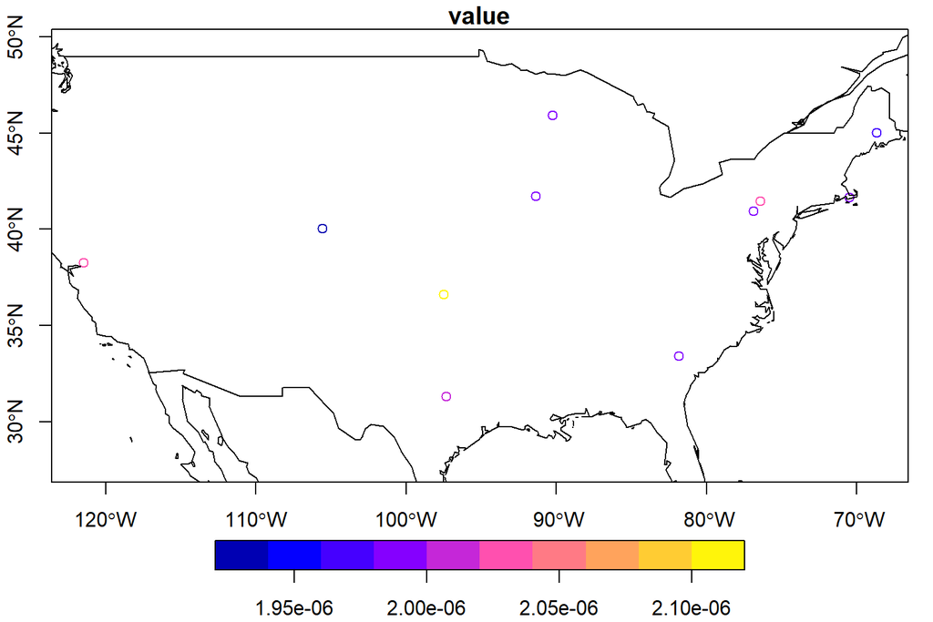

```r
library(sf)
dx <- df4[,
    lapply(.SD, mean),
    .SDcols = "value",
    by = .(latitude, longitude)]
x <- st_as_sf(dx, coords = c("longitude", "latitude"), crs = 4326)
plot(x["value"], axes = T, reset = F)
maps::map(add = T)
```